# DeepMetrica Customer Segmentation Analysis STEP 4 - Websites IN TURKEY Using Analytics and Tracking Technology Through Start Date

Tugrul Ozsoy

12 Kasım 2020

[figure not shown]

[figure not shown]

# 1 Introduction

The data we analyzed consisting of `1.351` paid and `53.567` free total websites using the technology of our main competitors and located in `Turkey`. The different types of websites have been spread over the types to see “WEBSITES CONSTITUTED THE FIRST SEGMENT WE WILL FOCUS ON HAVE WHICH TYPE AND INDUSTRIES” The dataset is exported with the help of `BuiltWith Pro`.

The line plots show that our competitor how many customers from Turkey our competitor web analytics services GAINED in each year between 2011-2020.

# 2 Paid

## 2.1 Hotjar

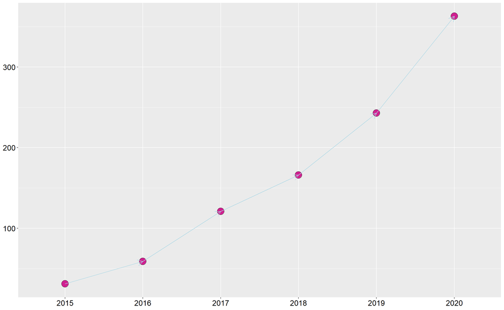

2015:

`bonus.com.tr` `kariyer.net` `nissan.com.tr` `obilet.com` `teknosa.com`

2016:

`iyzico.com` `boyner.com.tr` `beymen.com` `toyota.com.tr` `folkarttowers.com`

2017:

`trtworld.com` `turkcell.com.tr` `lcwaikiki.com` `defacto.com.tr` `yapikredi.com.tr`

2018:

`hilton.com.tr` `vakko.com` `groupama.com.tr` `arcelikglobal.com` `eczacibasi.com.tr`

2019:

`digiturk.com.tr` `roche.com.tr` `gratis.com` `qnbfinansbank.com` `arbys.com.tr`

2020:

`jeep.com.tr` `bim.com.tr` `fakir.com.tr` `paribu.com` `1x-bet.info.tr`

## 2.2 CrazyEgg

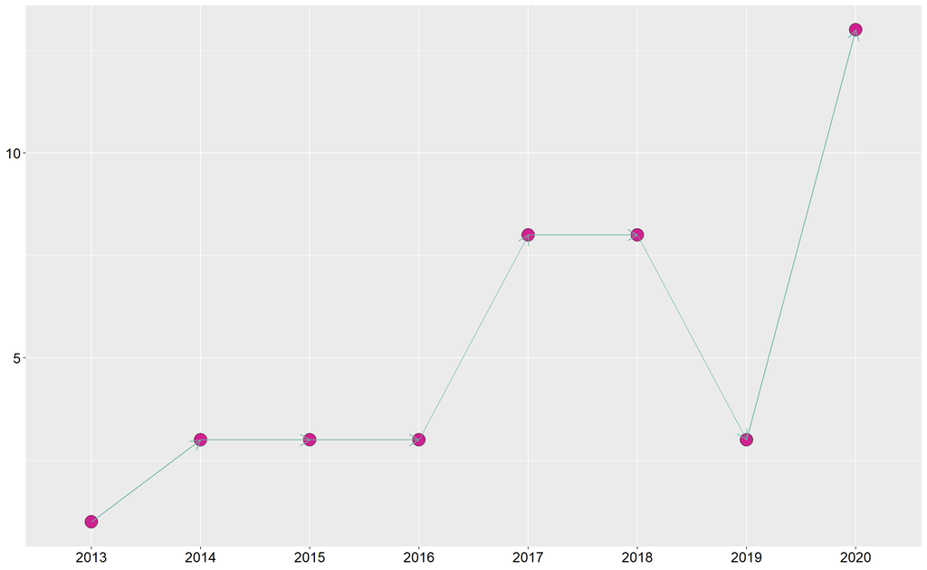

2013:

`ogbamermer.com`

2014:

`gittigidiyor.com` `shopio.com.tr` `fins.com.tr`

2015:

`cozumsepeti.com` `startkredi.com` `statkraft.com.tr`

2016:

`chado.com.tr` `tadek.com.tr` `qnet.com.tr`

2017:

`sandoz.com.tr` `qnetturkiye.com.tr` `wordapp.com.tr` `havhav.com.tr` `moka.com`

2018:

`pizzalazza.com.tr` `gastroclub.com.tr` `prity.com.tr` `astelled.com.tr` `mayasante.com.tr`

2019:

`ipara.com.tr` `migros.com.tr` `asusturkiye.com.tr` `gamer.com.tr` `satrancokulu.com`

## 2.3 Smartlook

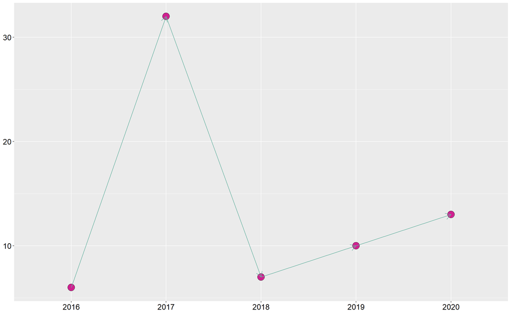

2016:

`samet.com.tr` `sezerstone.com` `soagen.com.tr` `ubf.com.tr` `exapro.biz.tr`

2017:

`naksibenditarikati.com` `sportbox.com.tr` `mikrofiber.com.tr` `altinevyapi.com` `mimozahuzurevi.com.tr`

2018:

`kulelievleri.com` `lodosyazilim.com.tr` `kocaktoys.com` `serverplus.com.tr` `maxipas.com.tr`

2019:

`tonermarket.com.tr` `sevil.com.tr` `shoebox.com.tr` `yegenleryapi.com` `megaradar.com.tr`

2020:

`ozelkalem.com` `isgdunyasi.com` `spotcularcarsisi.com` `akmetal.com` `arteland.com.tr`

## 2.4 Optimizely

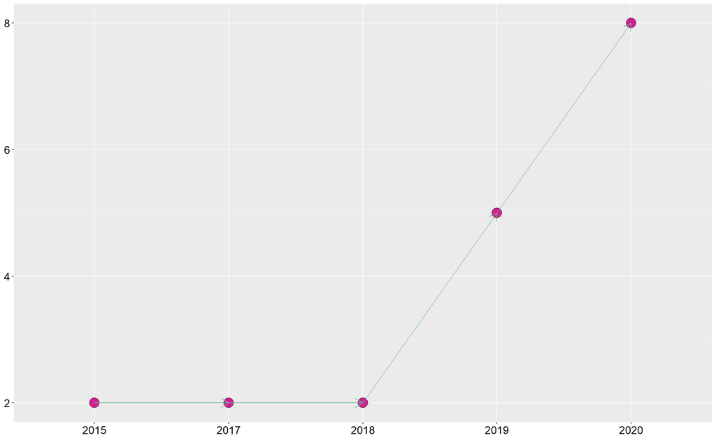

2015:

`dashboardegitim.com` `hairbuy.org`

2017:

`airfrance.com.tr` `mavigol.com.tr`

2018:

`klm.com.tr` `tofisi.com`

2019:

`nesetdemir.com.tr` `nureryuksel.com` `arda.pw` `autoscout24.com.tr` `aydenizsigorta.com`

2020:

`kocaelidenizyildizlari.com.tr` `segabakir.com.tr` `rapi.com.tr` `funnygames.com.tr` `mono.net.tr`

## 2.5 Mixpanel

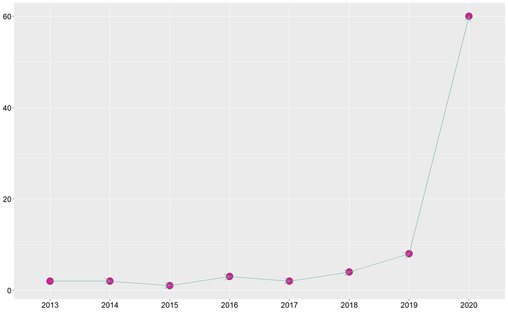

2013:

`casualdata.com` `siberalem.com`

2014:

`ganipara.com` `evlilikmerkezi.com`

2015:

`alokartvizit.com`

2016:

`neorionhotel.com` `anindafoto.com` `ansiklomedi.com`

2017:

`one.com.tr` `emo.org.tr`

2018:

`teknoglobal.com.tr` `sihappy.web.tr` `vermisol.com` `fieldpie.com.tr`

2019: `century21.com.tr` `dogasigorta.com` `gokhanaksoy.com.tr` `qsa.com.tr` `academica.com.tr`

2020:

`cosmofit.com.tr` `ku.edu.tr` `networkgayrimenkul.com.tr` `superoyunlar.org` `dugundavet.com`

## 2.6 Mouseflow

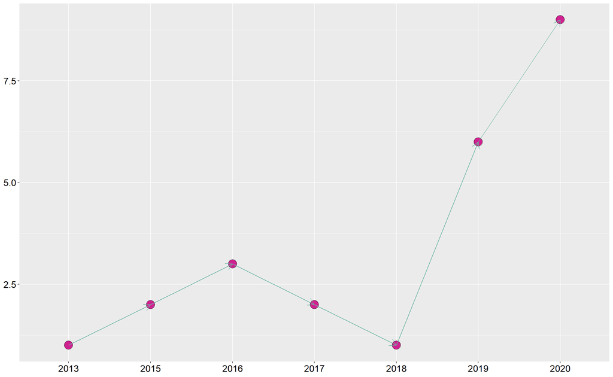

2013:

`ogrencikilavuzu.com`

2015:

`seliton.com.tr` `videojet.com.tr`

2016:

`nirvanahotel.com` `halisahalarim.com` `quipus.com.tr`

2017:

`igus.com.tr` `saillakers.com.tr`

2018:

`summercart.com.tr`

2019:

`bst-istanbul.com.tr` `continental-lastikleri.com.tr` `soniflex.com.tr` `bituline.com.tr` `geldeyeme.com.tr`

2020:

`kaburgadoner.com.tr` `kekiksofrasi.com.tr` `tintin.com.tr` `havatech.com.tr` `performist.com.tr`

## 2.7 Chartbeat

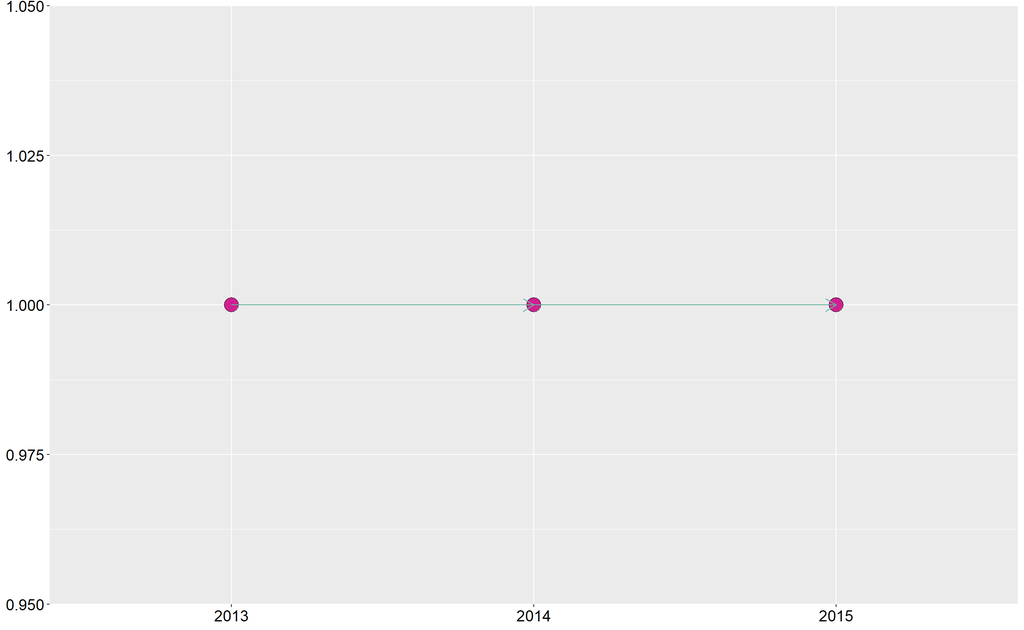

2013:

`burclar.gen.tr`

2014:

`aljazeera.com.tr`

2015:

`tiyatrolar.com.tr`

## 2.8 Snowplow

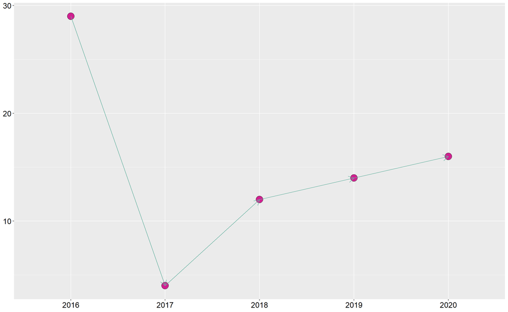

2016:

`kantin.com.tr` `tangoadana.com` `tezprojem.com` `makodivingbodrum.com` `mavikelebekcollection.com`

2017:

`kampyapi.com.tr` `nurettinagar.com` `techknowledge.com.tr` `personalife.com.tr`

2018:

`cokseslikoro.gov.tr` `kmkmoda.com.tr` `nkmdesign.net` `spin.com.tr` `startek.com.tr`

2019:

`bera.com.tr` `kordonotel.com.tr` `thecityhotel.com.tr` `anadoluhotels.com` `daphneconsulting.com.tr`

2020:

`operahotel.com.tr` `tapualacati.com.tr` `hotelmonec.com.tr` `gardenkalehotel.com.tr` `aferry.com.tr`

## 2.9 Woopra

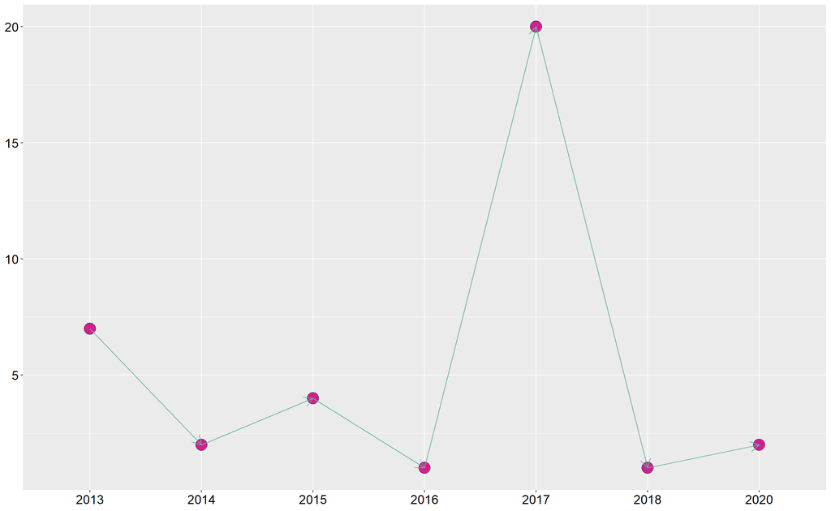

2013:

`devinimmuhendislik.com.tr` `laptoptamirhanesi.com` `uludag.edu.tr` `webprojeler.com` `yunus.gen.tr`

2014:

`kervan.com.tr` `golcuk.bel.tr`

2015:

`karelli.com.tr` `gastrorganik.com` `akcakocakulturplatformu.org` `eyb.com.tr`

2016:

`kivacrm.com`

2017:

`onurguven.com.tr` `buythebestchair.com` `takethebestchair.com` `ofiseaksesuar.com` `emailmarketing.com.tr`

2018:

`zytin.com.tr`

2020:

`inventiv.com.tr` `fitikistanbul.com.tr`

# 3 Free

## 3.1 Google Analytics

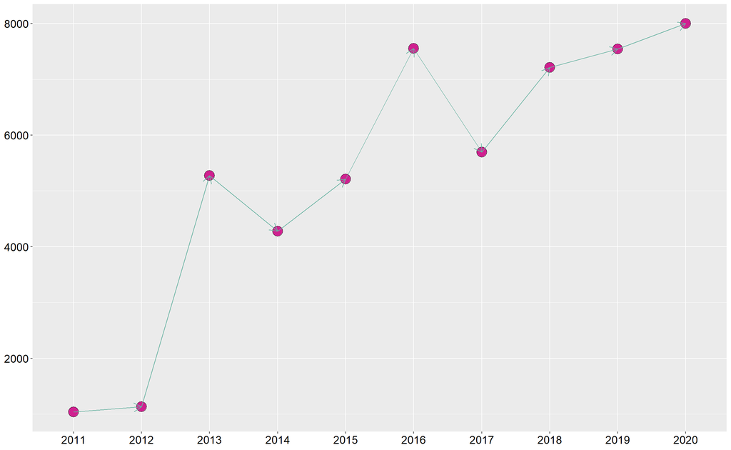

2011:

`boyner.com.tr` `burgerking.com.tr` `cimri.com`

2012:

`zurichsigorta.com.tr` `concord.com.tr` `yildizholding.com.tr`

2013:

`carrefoursa.com` `kigili.com` `teknosa.com`

2014:

`bilyoner.com` `kuveytturk.com.tr` `nef.com.tr`

2015:

`garanti.com.tr` `theistanbulinsider.com` `skoda.com.tr`

2016:

`turktelekom.com.tr` `ibb.istanbul` `izmirimkart.com.tr`

2017:

`baskent.edu.tr` `paribu.com` `isyatirim.com.tr`

2018:

`biletix.com` `oyak.com.tr` `tofas.com.tr`

2019:

`istanbuleczaciodasi.org.tr` `samsung.com.tr` `roche.com.tr`

2020:

`bim.com.tr` `15temmuz.gov.tr` `fordotosan.com.tr`

## 3.2 Yandex Metrika

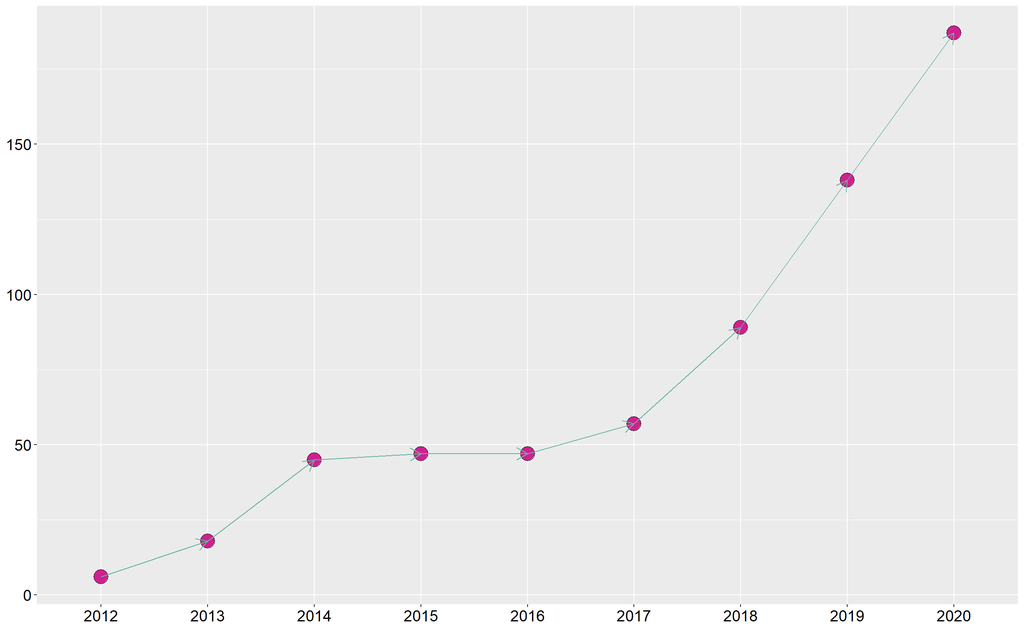

2012:

`falconelektronik.com` `makyajoyunu.biz.tr` `kizoyunlari.biz.tr`

2013:

`salonsemazen.com.tr` `macsonuclari.gen.tr` `bursahacamatmerkezi.com`

2014:

`isyelegi.org` `amacimizsaglik.com` `arkadaslik.com.tr`

2015:

`saglikocagim.net` `ucuzayakkabi.com.tr` `transferotele.com`

2016:

`macskoru.net` `magazinhabercim.com` `ucakbileti.com.tr`

2017:

`knightonline1.com` `semerkand.tv` `mefteknik.com.tr`

2018:

`photoshopegitim.com` `durmuslarotomotiv.com.tr` `seckinlerotomotiv.com.tr`

2019:

`elektriklikombi.com` `proaktifteknoloji.com.tr` `yalcinlarplastik.com.tr`

2020:

`izmirlazerepilasyon.com.tr` `qarabaghotel.com` `hacettepeliler.com.tr`